# Differential Expression Volcano Plot Analysis - Inv4m Effect

Fausto Rodriguez Zapata

2026-01-02

# Overview

**Purpose**: Generate volcano plot for Inv4m genotype effect on differential gene expression, highlighting genes selected by Mahalanobis distance outlier detection.

**Input**: CSV file containing differential expression results with Mahalanobis outlier identification (`is_selected_DEG` column) from the inversion paper DE analysis.

**Output**: - Inv4m volcano plot (Panel C for Figure 3) - Standalone volcano figure for manuscript

# Setup

## Load Libraries

```r
library(dplyr)
library(ggplot2)
library(ggrepel)
library(ggpubr)
```

# Data Import and Filtering

**Purpose**: Load differential expression results and filter to Inv4m genotype effect.

**Approach**: Import CSV and subset to Inv4m genotype effects. The input contains pre-calculated Mahalanobis distances and outlier flags from upstream analysis.

**Expected outcome**: Filtered dataset with Inv4m predictor, retaining all columns including `is_selected_DEG` for gene labeling.

```r
predictor_order <- "Inv4m"

# Load DE results with Mahalanobis outlier detection
effects_df <- read.csv(file.path(paths$intermediate, "predictor_effects_leaf_interaction_model.csv")) %>%
  filter(predictor %in% predictor_order) %>%
  droplevels()

# Set predictor factor

effects_df$predictor <- factor(effects_df$predictor, levels = predictor_order)

# Diagnostics
cat("Predictors in dataset (ordered):", levels(effects_df$predictor), "\n")
```

```
## Predictors in dataset (ordered): Inv4m
```

```r
cat("Total genes:", nrow(effects_df), "\n")
```

```
## Total genes: 24011
```

```r
cat("Genes per predictor:\n")
```

```
## Genes per predictor:
```

```r
print(table(effects_df$predictor))
```

```
##
## Inv4m
## 24011
```

# Gene Selection for Labeling

**Purpose**: Identify top genes to label in volcano plots based on Mahalanobis distance ranking.

**Expected outcome**: Data frame of genes to label, with custom label text from curated annotations.

```r
# Load curated labels from intermediate results
curated <- read.csv(file.path(paths$intermediate, "selected_DEGs_leaf_interaction_model.csv")) %>%
  select(
    regulation,
    predictor,
    gene,
    locus_symbol,
    locus_label,
    desc_merged,
    mahalanobis,
    logFC,
    neglogP
  )

# Set predictor order for curated data
curated$predictor <- factor(curated$predictor, levels = predictor_order)

# Define number of labels per predictor and regulation
label_counts <- data.frame(
  predictor = c("Inv4m", "Inv4m"),
  regulation = c("Downregulated", "Upregulated"),
  n_labels = c(15, 15),
  stringsAsFactors = FALSE
)

# Select genes for labeling based on specified counts
to_plot <- curated %>%
  ungroup() %>%
  filter(!is.na(locus_label) & locus_label != "") %>%
  arrange(regulation, predictor, -mahalanobis) %>%
  left_join(label_counts, by = c("predictor", "regulation")) %>%
  group_by(regulation, predictor) %>%
  mutate(row_num = row_number()) %>%
  filter(row_num <= n_labels) %>%
  select(-row_num, -n_labels) %>%
  arrange(-mahalanobis) %>%
  ungroup() %>%
  mutate(predictor = factor(predictor, levels = predictor_order)) %>%
  data.frame()

# Diagnostics
cat("Total curated genes:", nrow(curated), "\n")
```

```
## Total curated genes: 118
```

```r
cat("Genes with locus_label:", sum(!is.na(curated$locus_label) & curated$locus_label != ""), "\n")
```

```
## Genes with locus_label: 69
```

```r
cat("\nSelected DEGs by regulation and predictor:\n")
```

```
##
## Selected DEGs by regulation and predictor:
```

```r
with(curated, print(table(regulation, predictor)))
```

```
##                predictor
## regulation      Inv4m
##   Downregulated    11
##   Upregulated      14
```

```r
cat("\nGenes selected for labeling:", nrow(to_plot), "\n")
```

```
##
## Genes selected for labeling: 19
```

```r
cat("Labels per predictor/regulation:\n")
```

```
## Labels per predictor/regulation:
```

```r
with(to_plot, print(table(regulation, predictor)))
```

```
##                predictor
## regulation      Inv4m
##   Downregulated     7
##   Upregulated      12
```

```r
# Show configured label counts
cat("\nConfigured label counts:\n")
```

```
##
## Configured label counts:
```

```r
print(label_counts)
```

```
##   predictor    regulation n_labels
## 1     Inv4m Downregulated       15
## 2     Inv4m   Upregulated       15
```

# Visualization

## Inv4m Volcano Plot

**Purpose**: Create volcano plot showing logFC vs. FDR for Inv4m genotype effect.

**Approach**: Use ggplot with: - Points colored by regulation status (down/below threshold/up) - Text labels for top Mahalanobis-selected genes - Expression formatting for axis labels

**Expected outcome**: Single-panel figure saved as Panel C for Figure 3.

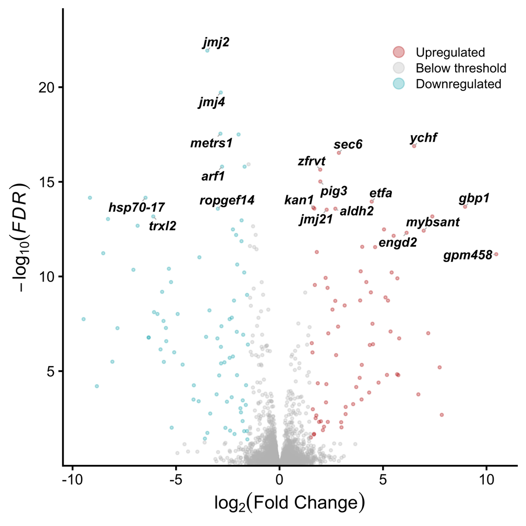

```r
# Custom formatting function for y-axis
scaleFUN <- function(x) sprintf("%.0f", x)

# Set regulation based on high-confidence DEG flag
effects_df$regulation[!effects_df$is_hiconf_DEG] <- "Unregulated"

# Generate Inv4m volcano plot
volcano_inv4m <- effects_df %>%
  ggplot(aes(x = logFC, y = neglogP, col = regulation)) +
  ylab(expression(-log[10](italic(FDR)))) +
  xlab(expression(log[2]("Fold Change"))) +
  scale_y_continuous(labels = scaleFUN, expand = expansion(mult = c(0, 0.1))) +
  geom_point(alpha = 0.3, size = 1) +
  geom_text_repel(
    data = to_plot,
    aes(label = locus_label),
    color = "black",
    fontface = "bold.italic",
    segment.color = "grey",
    force = 2,
    size = 5,
    min.segment.length = 0,
    max.overlaps = 50
  ) +
  scale_color_manual(
    name = "",
    values = c("#00AFBB", "grey", "#bb0c00"),
    labels = c("Downregulated", "Below threshold", "Upregulated")
  ) +
  guides(color = guide_legend(
    reverse = TRUE,
    override.aes = list(size = 5)
  )) +
  theme_classic2(base_size = 20) +
  theme(
    plot.title = element_blank(),
    legend.position = c(0.85, 0.90),
    legend.background = element_rect(fill = "transparent"),
    legend.spacing = unit(0, "line"),
    legend.box.spacing = unit(0, "line"),
    legend.text = element_text(size = 14),
    legend.direction = "vertical"
  )

# Save as RDS for assembly
saveRDS(volcano_inv4m, file.path(paths$intermediate, "volcano_inv4m.rds"))

# Save as Panel C for Figure 3
ggsave(
  file.path(paths$figures, "panels", "panel_C_volcano.png"),
  plot = volcano_inv4m,
  width = 6, height = 6, dpi = 300, bg = "white"
)

# Also save standalone figure
ggsave(
  file.path(paths$figures, "volcano_inv4m.png"),
  plot = volcano_inv4m,
  width = 8, height = 8, dpi = 150, bg = "white"
)

volcano_inv4m
```

# Summary

```r
cat("Inv4m Volcano Plot Analysis Complete\n")
```

```
## Inv4m Volcano Plot Analysis Complete
```

```r
cat("=====================================\n")
cat("Total genes analyzed:", nrow(effects_df), "\n")
```

```
## Total genes analyzed: 24011
```

```r
cat("Genes labeled in plot:", nrow(to_plot), "\n")
```

```
## Genes labeled in plot: 19
```

```r
cat("\nOutput files:\n")
```

```
##
## Output files:
```

```r
cat("  - Panel C: panels/panel_C_volcano.png\n")
```

```
##   - Panel C: panels/panel_C_volcano.png
```

```r
cat("  - Standalone: volcano_inv4m.png\n")
```

```
##   - Standalone: volcano_inv4m.png
```